# Goodreads Data Analysis of Performance Authors and Book

Lohansen

2019-07-23

# Data Introduction

This goodreads dataset contains a collection of information from books and novels that have been rated and reviews from readers. through this data we can analyze the correlation between the rating, the number of pages, the number of ratings, and the number of comments given to each book. This dataset available in [kaggle](https://www.kaggle.com/jealousleopard/goodreadsbooks)

# Let’s know more about the contents of the data

### Data Glossary

following are the Goodreads Book Dataset variable : - bookID Contains the unique ID for each book/series

- title contains the titles of the books
- authors contains the author of the particular book
- average_rating the average rating of the books, as decided by the users
- ISBN ISBN(10) number, tells the information about a book - such as edition and publisher
- ISBN 13 The new format for ISBN, implemented in 2007. 13 digits
- language_code Tells the language for the books
- Num_pages Contains the number of pages for the book
- Ratings_count Contains the number of ratings given for the book
- text_reviews_count Has the count of reviews left by users

### geting the basic ideas of data

first we have to read the dataset that has been prepared with the `read.` function, since my data is in the form of csv, the function I use is`read.csv`, then analyzes the data variable with the `str` function

```r
book <- read.csv("goodreadsbooks/books.csv")
str(book)
```

```
## 'data.frame':    13724 obs. of  10 variables:
##  $ bookID            : int  1 2 3 4 5 8 9 10 12 13 ...
##  $ title             : Factor w/ 12428 levels "","'Salem's Lot",..: 3808 3809 3812 3806 3811 3813 11750 3815 11082 11081 ...
##  $ authors           : Factor w/ 7606 levels "","A.B. Yehoshua-Hillel Halkin",..: 3044 3044 3044 3036 3044 3044 7248 3036 1696 1696 ...
##  $ average_rating    : Factor w/ 222 levels ""," Jr.-C.S. Lewis-P.G. Wodehouse-Michael Moorcock-L. Sprague de Camp-Fletcher Pratt-Eric Knight-Mervyn Peake-Pier"| __truncated__,..: 194 187 185 179 193 215 107 211 176 176 ...
##  $ isbn              : Factor w/ 13720 levels "","0.00","000100039X",..: 4973 4890 4932 4931 4953 4958 10416 4980 6001 3356 ...
##  $ isbn13            : Factor w/ 13720 levels "","0008987059752",..: 4996 4913 4955 4954 4976 4981 10428 5003 6024 3379 ...
##  $ language_code     : Factor w/ 36 levels "","9780674842113",..: 14 14 14 14 14 14 13 14 14 14 ...
##  $ X..num_pages      : Factor w/ 1093 levels "","0","1","10",..: 794 1007 426 463 555 361 204 442 956 956 ...
##  $ ratings_count     : int  1944099 1996446 5629932 6267 2149872 38872 18 27410 3602 240189 ...
##  $ text_reviews_count: int  26249 27613 70390 272 33964 154 1 820 258 3954 ...
```

### Adjusting the data

After knowing the variables that exist in the data, then we can then make adjustments to the data variable according to its contents. here I use the `as.` function to change and make adjustments to the data

```r
book$title <- as.character(book$title)
book$authors <- as.character(book$authors)
book$average_rating <- as.character(book$average_rating)
book$average_rating <- as.numeric(book$average_rating)
book$isbn <- as.integer(book$isbn)
book$isbn13 <- as.integer(book$isbn13)
```

# Data Exploration

#### load library

```r
library(ggplot2)
library(reshape2)
library(ggrepel)
```

#### 10 Most rated books

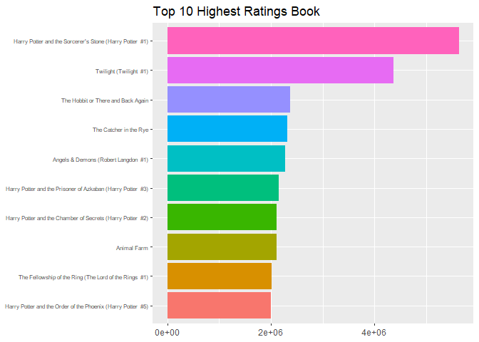

```r
book.msrt <- book[book$ratings_count > 1000000, ]
book.msrt <- book.msrt[order(book.msrt$ratings_count, decreasing = T),]
book.msrt$title <- factor(book.msrt$title, levels = book.msrt$title[order(book.msrt$ratings_count)])
book.10msrt <- head(book.msrt, 10)

ggplot(book.10msrt, aes(x = title, y = ratings_count))+
  geom_col(aes(fill = title))+
  coord_flip()+
  theme(axis.text.y = element_text(size = 6), legend.position = "none")+
  labs(x = NULL,
       y = NULL,
       title = "Top 10 Highest Ratings Book")
```

Insights : We can see that the beginning books of the series usually have most of the ratings, i.e, Harry Potter and the Sorcerer stone, Twilight, The Hobbit, Angels and demons.

Harry potter first book dominates the section by having more than 5.000.000 ratings. Infact, apart from a few, such as Catcher in the Rye and Animal Farm, all of the books seem to be from a series of books, getting the notion into our head that once people begin, most of them seem to dive in with the notion of completing it.

When we see at the first and fifth book of Harry Potter, we can also notice that there has been a huge margin in the number of readers/ratings for the books, signifying that there were people who did not pick up the next book in the series and/or only found the first book to touch their hearts up to an extent to drop a vote

#### The distribution of books in all languages

```r
options(scipen = 999)
lang <- c("ale","ara","cat","dan", "en-CA", "en-GB", "en-US", "eng", "enm", "fre", "ger", "gla", "glg", "grc", "heb", "ita", "jpn", "lat", "msa", "mul", "nl", "nor", "por", "rus", "spa", "srp", "swe", "tur", "wel", "zho")

book_clean <- book[book$language_code %in% lang,]
book_clean$language_code <- factor(book_clean$language_code)
levels(book_clean$language_code)
```

```
##  [1] "ale"   "ara"   "cat"   "dan"   "en-CA" "en-GB" "en-US" "eng"
##  [9] "enm"   "fre"   "ger"   "gla"   "glg"   "grc"   "heb"   "ita"
## [17] "jpn"   "lat"   "msa"   "mul"   "nl"    "nor"   "por"   "rus"
## [25] "spa"   "srp"   "swe"   "tur"   "wel"   "zho"
```

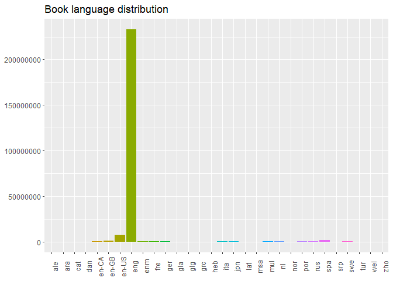

```r
ggplot(book_clean, aes(x = language_code, y = ratings_count))+
  geom_col(aes(fill = language_code))+
  theme(axis.text.x = element_text(angle = 90), legend.position = "none")+
  labs(x = NULL,
       y = NULL,
       title = "Book language distribution")
```

#### Ratings count and text reviews count distirbution

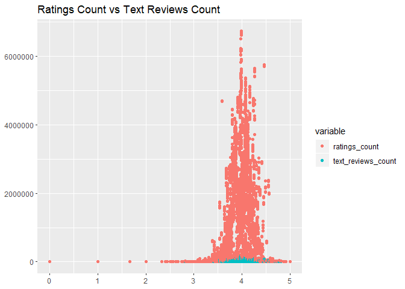

```r
book.popl <- melt(book, id.vars = "average_rating", measure.vars = c("ratings_count", "text_reviews_count"))

ggplot(book.popl, aes(x = average_rating, y = value))+
  geom_point(aes(col = variable), position = "stack")+
  labs(x = NULL,
       y = NULL,
       title = "Ratings Count vs Text Reviews Count")
```

Insights : through the plot above, it can be concluded that the distribution of rating and review of books is mostly in books with a rating of 3.5 - 4.5. and books that are given a rating of 1, 2 and 5 are very rare.

the amount of the rating also has a significant influence on giving a review. in books with a high rating, it also influences the giving of high reviews from readers.

#### Correlation between average rating and Ratings count

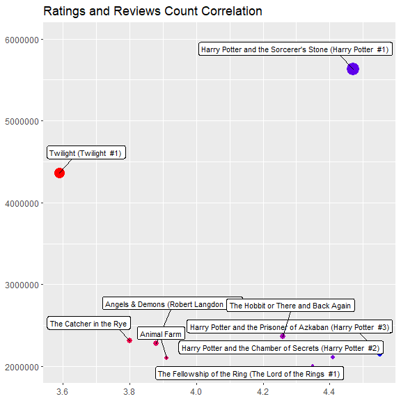

```r
book.hrtct <- book[book$ratings_count >= 2000000,]
book.hrtct_clean <- book.hrtct[complete.cases(book.hrtct),]

ggplot(book.hrtct_clean, aes(x = average_rating, y = ratings_count))+
  ylim(2000000, 6000000) +
  geom_point(aes(size = ratings_count, col = average_rating))+
    geom_label_repel(aes(label = title), nudge_y = 250000, size = 3)+
  scale_color_gradient(low = "red", high = "blue")+
  theme(legend.position = "none")+
  labs(x = NULL,
       y = NULL,
       title = "Ratings and Reviews Count Correlation")
```